# Bayesian Data Analysis, Part 2

Clay Ford

2026-02-13

## Agenda

- Review some basic concepts from Part 1
- Implement more complex Bayesian analyses
- model visualization
- model comparison

## Review: Bayesian statistics

- The objective of a Bayesian analysis is a *posterior distribution* of our parameters of interest
- To obtain a posterior distribution, we must start with a *prior distribution* and a *likelihood*
- Using *Markov chain Monte Carlo (MCMC)* we sample from the prior and likelihood to estimate the posterior distributions
- The `rstanarm` package allows us to perform common Bayesian analyses using familiar base R modeling syntax

## Review: Example

Examine two brands of rechargeable batteries. How long do they run (in hours) before exhausted?

- Take 25 samples of each brand and calculate mean time
- Calculate difference between means: $0.86$ hours
- Appears one brand is superior

## Review: a prior distribution

Perhaps we’re not sure which brand is better. A possible prior distribution might look like this, a $N(0,3)$ distribution.

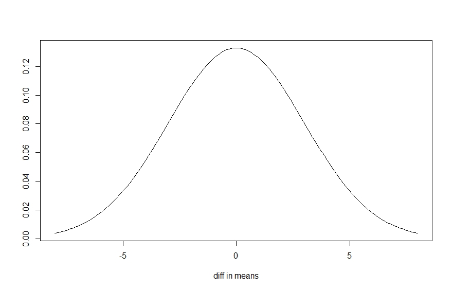

## Review: Implementation

```r
library(rstanarm)
bmod <- stan_glm(y ~ grp, data = bat,
                   family = gaussian,
                   prior = normal(0,3))
```

Bayesian uncertainty interval estimated from the posterior distribution:

```r
round(posterior_interval(bmod, prob = 0.95,
                         pars = "grp"),2)
```

```
    2.5% 97.5%
grp 0.39  1.33
```

## Review: plotting posterior distribution

```r
plot(bmod, plotfun = "dens", pars = "grp")
```

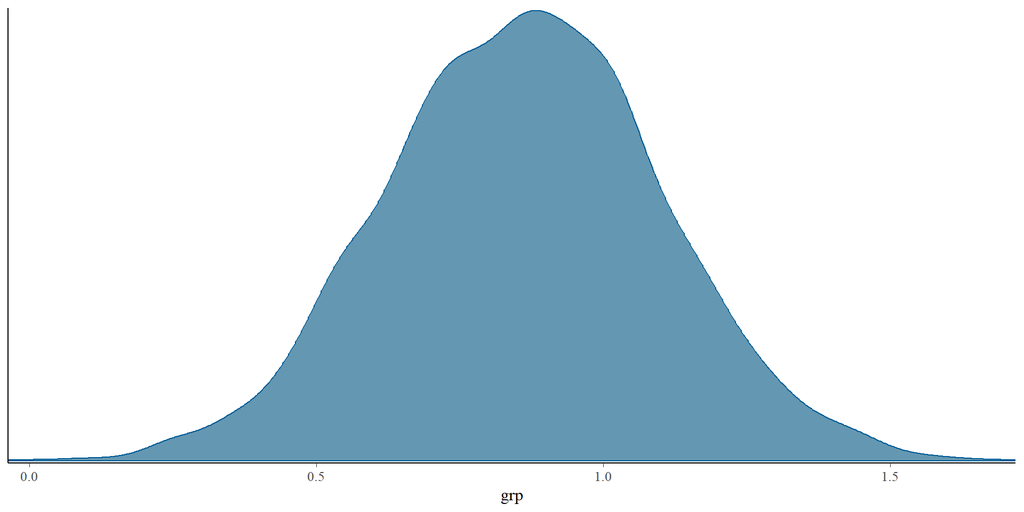

## Review: Working with posterior distribution

Let’s say we want to estimate the probability that the difference in battery life is:

- greater than 0
- greater than 1 hour

`as.data.frame()` creates a data frame of *posterior samples*.

```r
post <- as.data.frame(bmod)
mean(post$grp > 0)
```

```
[1] 0.99975
```

```r
mean(post$grp > 1)
```

```
[1] 0.28475
```

## Review: graphical posterior predictive checks

```r
pp_check(bmod)
```

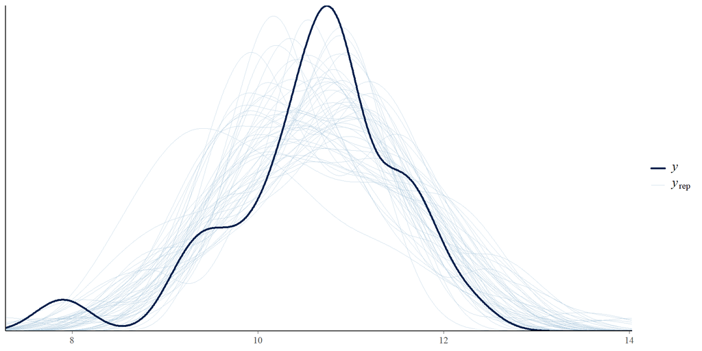

## Moving on to more complex analyses

The previous example was a simple *model* with one predictor. It was essentially the Bayesian approach to what is traditionally analyzed as a t-test.

Today’s workshop will cover more complicated analyses including:

- multiple regression
- regression with interactions
- binary logistic regression

## Multiple regression

Multiple regression, or linear modeling, is the idea that the variability of some numeric variable of interest can be “explained” by a sum of weighted predictors.

Example: patient satisfaction scores at a hospital. Some are high, some are low. Why? Perhaps it has do with their age, anxiety level, and illness severity.

$$\text{satisfaction} = \beta_0 + \beta_1 \text{age} + \beta_2 \text{anxiety} + \beta_3 \text{illness}$$

Where the betas represent some *weight*. Hence the term, *weighted sum*. $\beta_0$ is the intercept.

## Multiple regression

$$\text{satisfaction} = \beta_0 + \beta_1 \text{age} + \beta_2 \text{anxiety} + \beta_3 \text{illness}$$

This model says, “if I take age, anxiety level and illness severity, multiply each by some weight, and add them up, I’ll get an expected patient satisfaction score.”

The calculated value will be off by some amount. We assume this amount, usually denoted $\epsilon$, is a random draw from a Normal distribution with mean 0 and some unknown standard deviation, $\sigma$. This gives us

$$\text{satisfaction}_i = \beta_0 + \beta_1 \text{age} + \beta_2 \text{anxiety} + \beta_3 \text{illness} + \epsilon$$

Traditional multiple regression means estimating the betas and $\sigma$.

## Using `lm`

The traditional approach in R uses the `lm` function.

```r
ps <- read.csv("data/patient_satisfaction.csv")
m <- lm(ps ~ age + illness + anxiety, data = ps)
```

The betas (coefficients/weights) and $\sigma$ can be viewed with `coef` and `sigma`

```r
coef(m)
```

```
(Intercept)         age     illness     anxiety
158.4912517  -1.1416118  -0.4420043 -13.4701632
```

```r
sigma(m)
```

```
[1] 10.05798
```

## Using `glm`

We can also use `glm` for multiple regression. Note the `family` argument which allows us to specify the error distribution.

```r
m2 <- glm(ps ~ age + illness + anxiety, data = ps,
          family = gaussian)
coef(m2)
```

```
(Intercept)         age     illness     anxiety
158.4912517  -1.1416118  -0.4420043 -13.4701632
```

```r
sigma(m2)
```

```
[1] 10.05798
```

## The Bayesian approach

As before, instead of estimating parameters, the Bayesian approach is to **estimate the distributions of parameters**.

We propose prior distributions for the betas and $\sigma$, and update those distributions using a likelihood and the data.

## Likelihood

Recall our model:

$$\text{satisfaction}_i = \beta_0 + \beta_1 \text{age} + \beta_2 \text{anxiety} + \beta_3 \text{illness} + \epsilon$$

where $\epsilon \sim N(0,\sigma)$

This implies

$$\text{satisfaction}_i \sim N(\beta_0 + \beta_1 \text{age} + \beta_2 \text{anxiety} + \beta_3 \text{illness}, \sigma)$$

This is our *likelihood*: A normal, or Gaussian, distribution with a *conditional* mean that changes based on age, anxiety and illness.

Where traditional statistics maximizes likelihood, Bayesian statistics multiplies the likelihood by the prior to get a posterior distribution.

## Using `stan_glm`

The `stan_glm` function uses the same syntax as `glm` and provides *weakly informative* default prior distributions.<sup>1</sup>

```r
bm <- stan_glm(ps ~ age + illness + anxiety,
               data = ps,
               family = gaussian)
```

Instead of point estimates for the betas and $\sigma$, we get posterior distributions.

[^1]: On startup, rstanarm states “Default priors may change, so it’s safest to specify priors, even if equivalent to the defaults.”

## Evaluating and exploring the model

We proceed the same way as before to evaluate and explore the model.

```r
plot(bm, plotfun = "dens")
posterior_interval(bm)
summary(bm)
pp_check(bm)
```

Let’s go to R!

## Models with interactions

In our previous model, we assumed the predictor effects were simply additive. For example, it didn’t matter how ill you were, the effect of age was always the same.

$$\text{satisfaction} = \beta_0 + \beta_1 \text{age} + \beta_2 \text{anxiety} + \beta_3 \text{illness}$$

But we may have reason to believe the effects of age and illness interact. Perhaps the older you are, the effect of illness on patient satisfaction decreases.

One way to describe this interaction is to add the product of age and illness to the model:

$$\text{satisfaction} = \beta_0 + \beta_1 \text{age} + \beta_2 \text{anxiety} + \beta_3 \text{illness} + \beta_4 \text{age} \times \text{illness}$$

## Specifying interactions

Use a colon to specify interactions in the model syntax.

```r
bm2 <- stan_glm(ps ~ age + illness + anxiety +
                    age:illness,
               data = ps,
               family = gaussian)
```

Or use the asterisk as a shortcut: `age * illness` = `age + illness + age:illness`

```r
bm2 <- stan_glm(ps ~ age * illness + anxiety,
               data = ps,
               family = gaussian)
```

## The modeling result

Once again the target of the Bayesian model is the collection of posterior distributions on the model weights, or coefficients.

```r
posterior_interval(bm2)
```

```
                      5%          95%
(Intercept)  26.20181467 251.08202193
age          -3.42330550   2.16140201
illness      -2.33270503   2.20467749
anxiety     -25.84181972  -1.29440540
age:illness  -0.06550184   0.04424613
sigma         8.65894466  12.60598498
```

The interaction appears to be small and we’re uncertain whether it’s positive or negative.

## Visualizing interactions

Interaction coefficients are hard to interpret.

To aid in interpretation we can use *effect plots* to help us visualize our models.

The basic idea is to generate predictions for various combinations of predictors and plot the result.

## Using `ggeffects` to create effect plots

The `ggeffects` package provides methods for easily creating effect plots for models created with `rstanarm`.

The basic syntax to quickly generate an effect plot for our interaction:

```r
library(ggeffects)
ggpredict(bm2, terms = c("age","illness")) |>
  plot()
```

The following plot shows that the interaction between age and illness is small and virtually non-existent.

## An effect plot for `age:illness`

```r
library(ggeffects)
ggpredict(bm2, terms = c("age","illness")) |>
  plot()
```

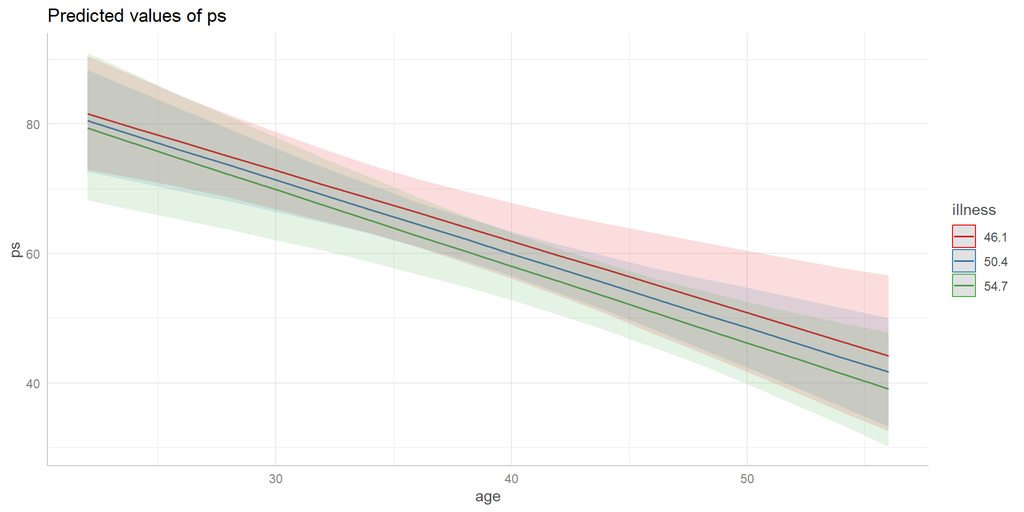

## Customizing the effect plot

We can specify predictor values as follows:

```r
ggpredict(bm2, terms = c("age","illness[45,50,55]")) |>
  plot()
```

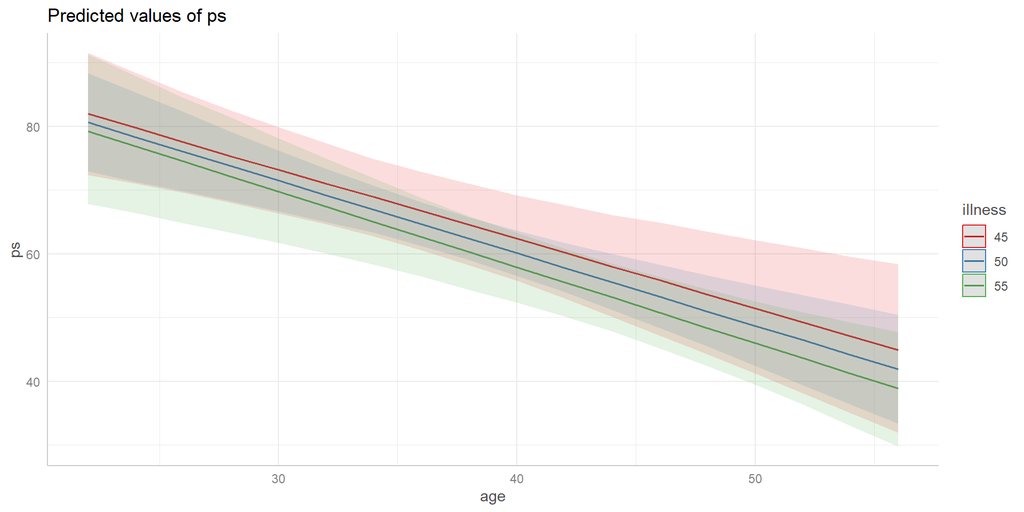

## Effect plots for main effects

Effect plots are useful for main effects as well (i.e., predictors not involved in an interaction)

```r
ggpredict(bm2, terms = "anxiety") |> plot()
```

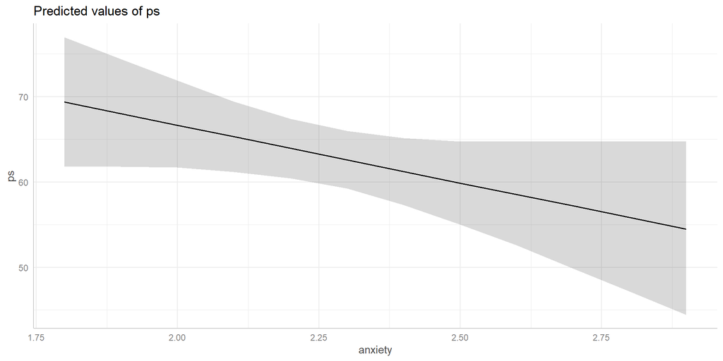

The 95% credibility ribbon is for the *mean* response value. Let’s go to R!

## Logistic regression

Logistic regression models the probability of a binary outcome. The dependent variable is often of the form 0/1, failure/success or no/yes.

Like multiple regression, we model probability as a weighted sum of predictors.

Unlike multiple regression, there is no $\sigma$ and the weighted sum of predictors are embedded in the *logistic* function:

$$P(Y=1) = \frac{1}{1 + \text{exp}(-X\beta)}$$

where $X\beta = \beta_0 + \beta_1X_1 + \beta_2X_2 + \ldots + \beta_kX_k$

This ensures our model always returns values between 0 and 1.

## The logit transformation

We can express the logistic regression model as a simple weighted sum of predictors by using the *logit* transformation:

$$\text{log} \left( \frac{P(Y = 1)}{1 - P(Y = 1)} \right) = \beta_0 + \beta_1X_1 + \ldots + \beta_kX_k$$

In this transformation, the response and coefficients are on the *log odds* scale.

This is the form logistic regression takes when performed in R (or any other program).

## Likelihood

Since we’re modeling the probability of an event happening, our response variable has a binomial distribution with *n* = 1:

$$Y \sim B\left(n = 1, p = \frac{1}{1 + \text{exp}(-X\beta)} \right)$$

While traditional statistics maximizes this likelihood, Bayesian statistics multiplies the likelihood by the prior to get a posterior distribution.

## Logistic regression example

A clinical trial investigates a new treatment for rheumatoid arthritis. Model probability of seeing improvement in condition based on treatment, sex, and age.

```r
head(arthritis)
```

```
  Treatment    Sex Age Better
1   Placebo Female  54      0
2   Treated Female  69      0
3   Treated   Male  27      1
4   Treated Female  62      1
5   Placebo   Male  44      0
6   Treated   Male  70      1
```

$$\text{log} \left( \frac{P(\text{Better} = 1)}{1 - P(\text{Better} = 1)} \right) = \beta_0 + \beta_1\text{Trt} + \beta_2\text{Sex} + \beta_3\text{Age}$$

## Fitting the model

The traditional method uses `glm`. Notice we set `family = binomial` since our response is binary.

```r
glm1 <- glm(Better ~ Treatment + Sex + Age,
            data = arthritis,
            family = binomial)
```

The `rstanarm` specification is virtually identical, except we use `stan_glm`

```r
bglm1 <- stan_glm(Better ~ Treatment + Sex + Age,
                  data = arthritis,
                  family = binomial)
```

The default coefficient priors are the same as those used when performing multiple regression. The intercept has location = 0.

## Interpreting the coefficients

Recall Bayesian modeling does not return point estimates for the coefficients (the betas) but rather distributions. To get a coefficient value, we typically take the median or the mean of the posterior distribution.

The `coef` function returns the median values.

```r
coef(bglm1)
```

```
     (Intercept) TreatmentTreated          SexMale              Age
     -3.11556378       1.74090082      -1.45083163       0.05044402
```

Exponentiating the coefficient value returns an odds ratio.

The odds that `Better = 1` is about 6 times higher for the Treated group: $\text{exp}(1.74) \approx 5.7$

## Using effect plots with logistic regression models

An effect plot can help communicate a model in terms of probability.

```r
ggpredict(bglm1, terms = "Treatment") |> plot()
```

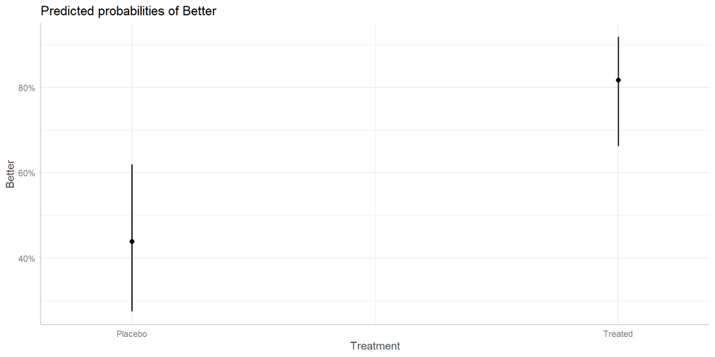

Let’s go to R!

## Model comparison

Let’s say we have the following models:

$$y = \beta_0 + \beta_1x1$$

$$y = \beta_0 + \beta_1x1 + \beta_2x2$$

$$y = \beta_0 + \beta_1x1 + \beta_2x2 + \beta_3x1 \times x2$$

Which model is “best”?

## Model comparison

In traditional statistics, models are often compared using hypothesis tests or information criteria such as AIC or BIC.

```r
m1 <- glm(y ~ x1, data = d, family = gaussian)
m2 <- glm(y ~ x1 + x2, data = d, family = gaussian)
m3 <- glm(y ~ x1 + x2 + x1:x2, data = d, family = gaussian)
anova(m1, m2, m3) # partial F tests
AIC(m1, m2, m3)
BIC(m1, m2, m3)
```

The partial F test approach requires “nested” models.

## Cross Validation

Models can also be compared using Cross Validation (CV).

1. Fit a model with portion of data held out
2. Use the fitted model to predict outcome for held out data
3. Calculate “performance” using a metric such as mean squared error: $\frac{1}{n}\sum_{i=1}^{n} (y_i - \hat{y_i})^2$
4. Repeat 1-3 such that all data gets a turn being held out
5. Take average of performance

Do CV for all models. A model with lower mean squared error is presumably better.

## Leave One Out CV

Leave One Out (LOO) CV leaves one observation out a time. This can be computationally demanding.

The loo package implements LOO CV for Bayesian models. rstanarm calls this package to allow for model comparisons.

The `loo()` function uses a mathematical “shortcut” that approximates the LOO performance while only fitting the model once.

## Bayesian model comparison

Use the `loo()` function to carry out LOO CV, then compare models using `loo_compare()`.

```r
bm1 <- stan_glm(y ~ x1, data = d, family = gaussian)
bm2 <- stan_glm(y ~ x1 + x2, data = d, family = gaussian)
bm3 <- stan_glm(y ~ x1 + x2 + x1:x2, data = d, family = gaussian)
loo1 <- loo(m1)
loo2 <- loo(m2)
loo3 <- loo(m3)
loo_compare(loo1, loo2, loo3)
```

## `loo_compare()` output

```
        elpd_diff se_diff
model 3  0.0       0.0
model 2 -1.6       3.1
model 1 -4.1       4.0
```

- The output reports the *difference* in expected log predictive density (ELPD) along with the standard error of the difference.
- ELPD summarizes predictive performance. Higher is better.
- Model listed first is the “best” of the three.
- Each comparison is to the first model.
- According to Gelman et al (2020), “differences smaller than 4 are hard to distinguish from noise”

Let’s go to R one last time!

## Some journal articles using `rstanarm`

- Espe, M. et al. (2016) Yield gap analysis of US rice production systems shows opportunities for improvement. *Field Crops Research*, 196:276-283.
- Kubrak, O. et al. (2017) Adaptation to fluctuating environments in a selection experiment with Drosophila melanogaster. *Ecology and Evolution*, 7:3796-3807.
- Herzog, S. et al. (2017) Sun Protection Factor Communication of Sunscreen Effectiveness. *JAMA Dermatology*, 153(3):348-350.
- Kovic, M. and Hänsli, N. (2017) The impact of political cleavages, religiosity, and values on attitudes towards nonprofit organizations. *Social Sciences*, 7(1), 2.
- Schnase, J. L., Carroll, M. L., Montesano, P. M., & Seamster, V. A. (2025, September 1). Shifts in breeding phenology for Cassin’s Sparrow (Peucaea cassinii) over four decades. *Journal of Field Ornithology*, 96(3), 1 - 11. Retrieved from https://doi.org/10.5751/JFO-00691-960303.

## References

- Gelman, A., Hill, J, & Vehtari, A. (2020) *Regression and Other Stories*. Cambridge University Press. https://avehtari.github.io/ROS-Examples/
- Goodrich B, Gabry J, Ali I & Brilleman S. (2025). rstanarm: Bayesian applied regression modeling via Stan. R package version 2.32.2 https://mc-stan.org/rstanarm.
- McElreath, M. (2016). *Statistical Rethinking*. CRC Press. Boca Raton.
- Muth, C., Oravecz, Z., & Gabry, J. (2018). User-friendly Bayesian regression modeling: A tutorial with rstanarm and shinystan. *The Quantitative Methods for Psychology*, 14(2), 99-119.
- Nicenboim, B., Schad, D., and Vasishth, S. (2021) An Introduction to Bayesian Data Analysis for Cognitive Science. https://vasishth.github.io/bayescogsci/book/
- Vehtari, A., Gelman, A. & Gabry, J. Practical Bayesian model evaluation using leave-one-out cross-validation and WAIC. *Stat Comput* 27, 1413–1432 (2017). https://doi.org/10.1007/s11222-016-9696-4

## Thanks for coming

- For free statistical consulting, contact us: `statlab@virginia.edu`
- Sign up for more workshops or see past workshops:  
  https://library.virginia.edu/data/training
- Register for the Research Data Services newsletter to be notified of new workshops:  
  https://library.virginia.edu/data/newsletters